# Exploring Stage IA Non-Small Cell Lung Cancer in the SEER Database

Kanhua Yin

December 10, 2017

## Introduction

Lung cancer is one of the most common malignancies and the leading cause of cancer-related death both nationally and internationally [1]. Based on pathological types, approximately 95% of all lung cancer can be classified as either small cell lung cancer (SCLC) or non-small cell lung cancer (NSCLC). The former one is a disseminated disease in most patients at presentation and associated with very poor prognosis. Even for SCLC patients with limited stage diseases, the median survival ranges from 15-20 months, and the reported 5-year survival rate is 10-13%. In contrast, NSCLC is associated with relatively better prognosis and accounts for 85% of all lung cancer cases in the US.This project focused on the NSCLC [2].

Clinically, one of the most important initial workup of lung cancer is assessing the cancer stage. The main goal of staging is to guide clinicians to select different treatment therapies (surgery, chemotherapy, radiotherapy, and palliative care) as well as to provide the different prognosis information. The Tumor, Node, Metastasis (TNM) staging system for NSCLC is an internationally accepted system used to characterize the extent of disease [3]. In this study, we will mainly focus on the Stage IA NSCLC (i.e. TNM classification T1a/1bN0M0), meaning the tumor size is less than 3 cm and there is no lymph node invasion or distal metastasis (i.e. cancer goes to other organs).

The database we used is the population-based Surveillance, Epidemiology, and End Results (SEER) registry. Currently, SEER covers approximately 28% of the US population and one the most popular population-based cancer database in the world. It contains comprehensive information of different types of cancers and a wide time period coverage (the current version: 1978-2014) [4]. This study mainly focused on the NSCLC patients from 2004-2014, as the 6th version of NSCLC staging was published and implemented in 2004. This study aims to use the SEER database to explore the impacts of different factors on the stage IA NSCLC survival.

## Defining patient cohort

```r
library(dplyr)
library(scales)
```

Please edit the path according to your system

```r
load("/Users/yinkanhua/Desktop/Harvard/!!!Fall courses/BST 260 Data Science/Final project/code and data_project/cancDef.rdata")
```

The whole database contains 9,663,315 patients. We firstly filter the lung cancer from the whole data by using the variable “cancer”. The year of diagnosis was limited to 2004 and beyond as the staging information (AJCC 6th and 7th edition) were only available since 2004. Actually, if we want, we can reclassify the prior patients’ cancer staging according to different AJCC versions. However, as the treatment protocols/standards for stage IA cancer was updated/changed rapidly, especially for the surgery therapies (such as the implementation of minimally invasive surgery), data from > 10 years ago may not be able to well reflect today’s condition. Due to this reason, we only choose the year of diagnosis >=2004.

```r
dat_lung <- canc %>% filter(cancer=='lung') %>% filter(yrdx>=2004)
```

According to the definition of stage IA NSCLC, the TNM stage is either T1N0M0 (AJCC 6th) or T1a/1bN0M0 (AJCC 7th). The T, N, and M refers to tumor size, lymph node, and metastasis, respectively (mentioned above). We used the following code the control the “N” and “M”.

Note: “dajcc” means the AJCC 6th edition.“dajcc7” means the AJCC 7th edition.

```r
dat_lung <- dat_lung %>% filter(dajccn %in% c(0,88,NA)) %>%
  filter(dajcc7n %in% c(0,888,NA)) %>% filter(dajccm %in% c(0,88,NA)) %>% filter(dajcc7m %in% c(0,888,NA))

dat_lung$index1 <- dat_lung$dajccn == 0
dat_lung$index2 <- dat_lung$dajccm == 0

dat_lung$index3 <- dat_lung$dajcc7n == 0
dat_lung$index4 <- dat_lung$dajcc7m == 0

dat_lung$index_ajcc <- dat_lung$index1 + dat_lung$index2
dat_lung$index_ajcc7 <- dat_lung$index3 + dat_lung$index4

dat_lung <- dat_lung %>% filter(index_ajcc == 2 | index_ajcc7 == 2)
```

Now we need to deal with the “T”. The classification of T is different in AJCC 6th and 7th. From the code book, among dajcc7t, 120 = T1a, 150 = T1b, and 888 = Not applicable. Among dajcc, 10 = T1, 88= Not applicable. However, we found even 888 means NA, many “NA” still exist in dajcc7t. Therefore, we used the following data to deal with the missing data.

```r
dat_lung <- dat_lung %>% filter(dajcc7t %in% c(120,150,888,NA)) %>% filter(dajcct %in% c(10,88, NA))

dat_lung$index5 <- dat_lung$dajcc7t %in% c(888,NA)
dat_lung$index6 <- dat_lung$dajcct %in% c (88, NA)

dat_lung$index_ajcct <- dat_lung$index5 + dat_lung$index6
dat_lung <- dat_lung %>% filter(index_ajcct!=2)
```

As mentioned in the introduction section, based on pathological types, lung cancer can be roughly classified as SCLC and NSCLC.

Here are the frequencies of different pathological types

```r
table(dat_lung$histo3)
```

```
##
##  8000  8001  8002  8004  8005  8010  8012  8013  8014  8015  8020  8021
##  1915     4     1     5     1  2029   689   452     1     2    18     6
##  8022  8030  8031  8032  8033  8041  8042  8043  8044  8045  8046  8050
##    32     2    13    32    68  1275    31     1     6   126  3889    25
##  8051  8052  8070  8071  8072  8073  8074  8075  8076  8078  8082  8083
##     1    17 12735   739   388    18    25     3     1     1    17    88
##  8084  8123  8140  8141  8144  8200  8201  8230  8240  8241  8244  8245
##    20    25 23509     2     3    24     5    48  1697     1    14     1
##  8246  8249  8250  8251  8252  8253  8254  8255  8260  8263  8290  8310
##   784   225  4006    20   685   397    66  1981   691     1     3    98
##  8323  8333  8430  8441  8470  8471  8480  8481  8490  8500  8507  8550
##   126     8    93     2     3     2   910   202    34     1     7  1159
##  8551  8560  8562  8570  8572  8574  8575  8576  8720  8743  8940  8980
##     1  1021     2     1     1    34     1     2     8     1     1    11
```

Therefore, we need to exclude the SCLC, benign tumor, and other irrelevant types from our cohort. The pathological types were coded according to the third edition of International Classification of Diseases for Oncology (ICD-O-3). Please refer to that for the details.

```r
dat_lung_final <- dat_lung %>% filter(!histo3 %in% c(8000, 8001, 8002, 8010, 8020, 8021, 8041, 8042, 8043, 8044, 8045, 8050, 8051, 8052, 8240, 8260, 8263, 8290, 8310, 8323, 8441, 8471, 8551, 8560, 8720, 8743, 8940, 8980))
```

Now, we have defined our cohort with a total of 53475 stage IA NSCLC patients from 2004-2014 in SEER database.

## Reclassification

The covariates we are interested in are age, sex, race, marital status, pathological type, tumor grade, and surgery type. The outcomes are survival status (dead vs alive) and survival time.

Firstly, we reclassified age to 6 categories:

```r
dat_lung_final$agec_per10 =
  ifelse(dat_lung_final$agedx<=40,1,
         ifelse(dat_lung_final$agedx>=41&dat_lung_final$agedx<=50,2,
                ifelse(dat_lung_final$agedx>=51&dat_lung_final$agedx<=60,3,
                       ifelse(dat_lung_final$agedx>=61&dat_lung_final$agedx<=70,4,
                              ifelse(dat_lung_final$agedx>=71&dat_lung_final$agedx<=80,5,
                                     ifelse(dat_lung_final$agedx>=80, 6, NA))))))
```

Sex (male and female)

```r
dat_lung_final$sex2 <- NA
dat_lung_final$sex2[dat_lung_final$sex=='male'] <- 1   # 1=male
dat_lung_final$sex2[dat_lung_final$sex=='female'] <- 0   # 0=female
```

Race (white, black, and others)

```r
dat_lung_final$race3 <- 3   # 3 = Others
dat_lung_final$race3[dat_lung_final$racreca==1] <- 1 # 1 = White
dat_lung_final$race3[dat_lung_final$racreca==2] <- 2 # 2 = Black
dat_lung_final$race3[dat_lung_final$racreca==9] <- NA
dat_lung_final$race3 <- as.factor(dat_lung_final$race3)
```

Marital status (married and non-married) It is associated with Socioeconomic status and some studies have pointed out the its association with cancer survival [5].

```r
dat_lung_final$marstat2 <- NA
dat_lung_final$marstat2 <- 0 # 0=non-married
dat_lung_final$marstat2[dat_lung_final$marstat==2] <- 1 # 1=married
dat_lung_final$marstat2[dat_lung_final$marstat==9] <- NA
```

Pathological types (squamous cell carcinoma, adenocarcinoma, and large cell tumor) Notably, in the current study, we mainly focused on above three major types of NSCLC and treated other rare pathological types as NA.

```r
dat_lung_final$histo3_2 <- NA
dat_lung_final$histo3_2[dat_lung_final$histo3 %in% c(8070, 8071, 8072, 8073, 8074, 8075, 8076, 8078, 8083, 8084)] <- 1 # 1 = squamous cell carcinoma
dat_lung_final$histo3_2[dat_lung_final$histo3 %in% c(8140, 8141, 8144, 8200, 8201, 8230, 8251, 8253, 8254, 8255, 8333, 8470, 8480, 8481, 8490, 8500, 8550, 8570, 8572, 8574, 8576)] <- 2 # 2 = adenocarcinoma
dat_lung_final$histo3_2[dat_lung_final$histo3 %in% c(8012, 8013, 8014)] <- 3 # 3 = large cell tumor
```

Grade (I,II,III, and IV) It should be noted that clinically, grade is different from TNM staging. Staging is based on the tumor size, lyphm node invasion, and diatal metasis. Grade is based on the cell differentiation. You can try to understand in this way: the more werid the cell looks like (compared with normal cell morphology), the higher its grade is.

```r
dat_lung_final$grade2 <- NA
dat_lung_final$grade2 [dat_lung_final$grade==1] <- 1 # 1=grade I
dat_lung_final$grade2 [dat_lung_final$grade==2] <- 2 # 2=grade II
dat_lung_final$grade2 [dat_lung_final$grade==3] <- 3 # 3=grade III
dat_lung_final$grade2 [dat_lung_final$grade==4] <- 4 # 4=grade IV
```

```r
dat_lung_final$surgtype <- NA
dat_lung_final$surgtype[dat_lung_final$surgprif %in% c(20, 21, 22, 23, 24, 25)] <- 1  # 1 = sublobar resection
dat_lung_final$surgtype[dat_lung_final$surgprif %in% c (30, 33, 45, 46, 47, 48)] <- 2  # 2 = lobectomy
dat_lung_final$surgtype[dat_lung_final$surgprif %in% c (55, 56, 65, 66, 70)] <- 3 # 3 = pneumonectomy
dat_lung_final$surgtype[dat_lung_final$surgprif %in% c (0)] <- 4 # 4 = no surgery
```

Outcomes:

Dead vs alive:

```r
dat_lung_final$die2[dat_lung_final$statrec==1] <- 0 # 0 = alive
dat_lung_final$die2[dat_lung_final$statrec==4] <- 1 # 1 = dead
```

Survival months: The SEER database contains a variable called “survival months (srv_time_mon, surv_month)”

Let’s put all above together and filter the wrong number of survival months (The longest survival from Jan 2004 to Dec 2014 = 12*11=132 months)

```r
dat_lung_analy <- dat_lung_final %>% select(casenum, agedx, agec_per10, sex2, race3, marstat2, histo3_2, grade2, surgtype, die2, surv) %>% filter(surv<=132)
```

## Age effect

Let’s first look at the age distribution in the patient cohort:

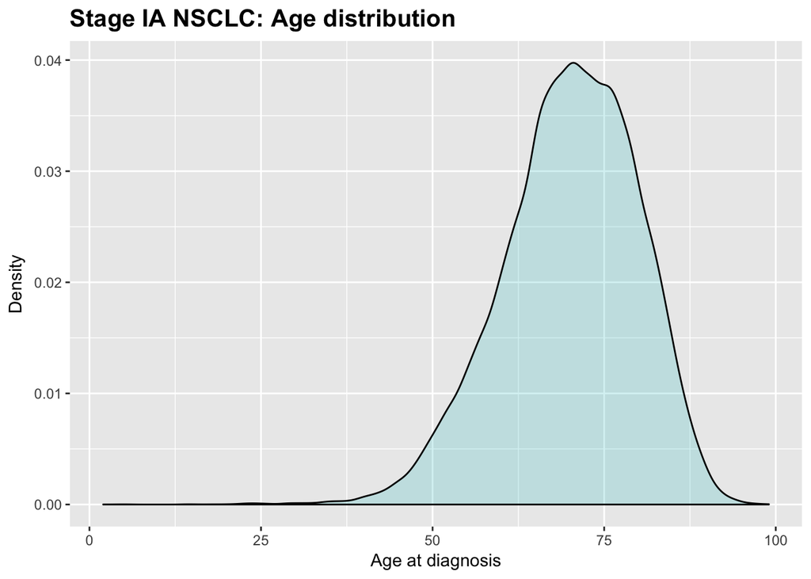

```r
library(ggplot2)
dat_lung_analy %>%
  ggplot(aes(agedx)) +
  geom_density(alpha=.2, fill= "#00BFC4")  +
  xlab("Age at diagnosis") +
  ylab("Density") +
  ggtitle("Stage IA NSCLC: Age distribution") +
  theme(plot.title = element_text(size=15, face="bold"))
```

Not surprisingly, the peak is 65-70 years old. Few patients were under 40.

Let’s look at the long-term survival across different age categories

```r
library(survival)
library(survminer)
```

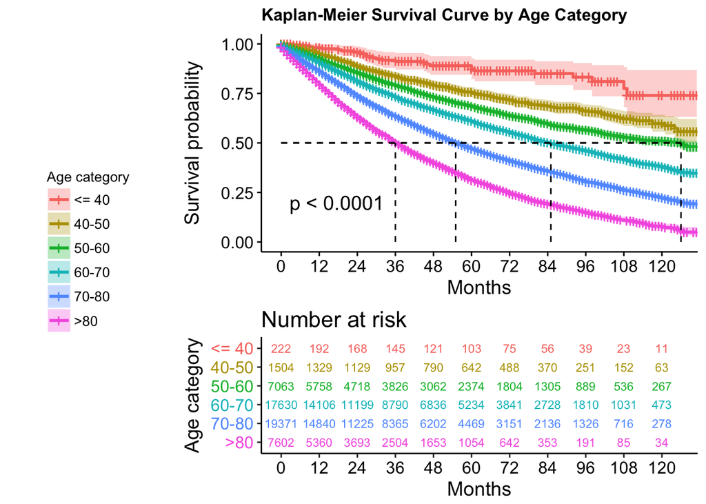

```r
fit2 <- survfit(Surv(surv, die2) ~ agec_per10, data = dat_lung_analy, type = "kaplan-meier")
ggsurvplot(fit2, data = dat_lung_analy, pval=TRUE, risk.table.y.text.col = T, title = "Kaplan-Meier Survival Curve by Age Category", font.title = c (12, "bold"), xlab = "Months",ylab = "Survival probability", legend = "left", legend.title = "Age category", legend.labs = c("<= 40", "40-50", "50-60", "60-70", "70-80", ">80"), conf.int = TRUE, risk.table = TRUE, risk.table.height = 0.4, risk.table.col = "strata", risk.table.fontsize = 3, break.time.by = 12, surv.median.line = "hv")
```

This figure clearly shows that with the increasing of age, the long-term survival is becoming worth, even for this early stage lung cancer.

## Surgery types and outcomes

As a cardiothoracic surgeon, the primary author of this study was very much interested in the outcomes of different surgery types.

To provide a easy way to understand different lung cancer procedures, we added a figure here. The bottom two are two classical types of sublobar resection.

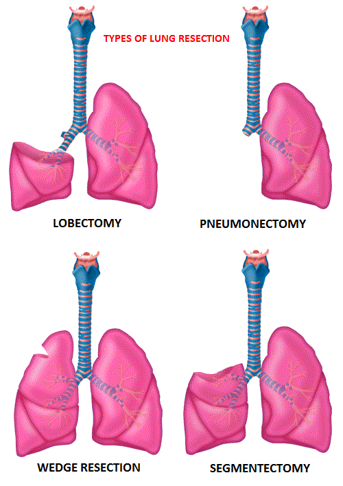

```r
knitr::include_graphics("https://www.oncoprescribe.com/oncoprescribe.com/app/uploads/_1456410266.gif")
```

You can get a general idea from above picture that the pneumonectomy is the “biggest” (most invasive) procedure among these three. Lobectomy is a procedure that removing at least one leaf of lung lobe (Don’t worry, we have two lobes in our left lung and three in our right lung). Sublobar resection is considered less invasive as it only removes a limited portion of the lung lobe.

Great! Let’s look at their performance:

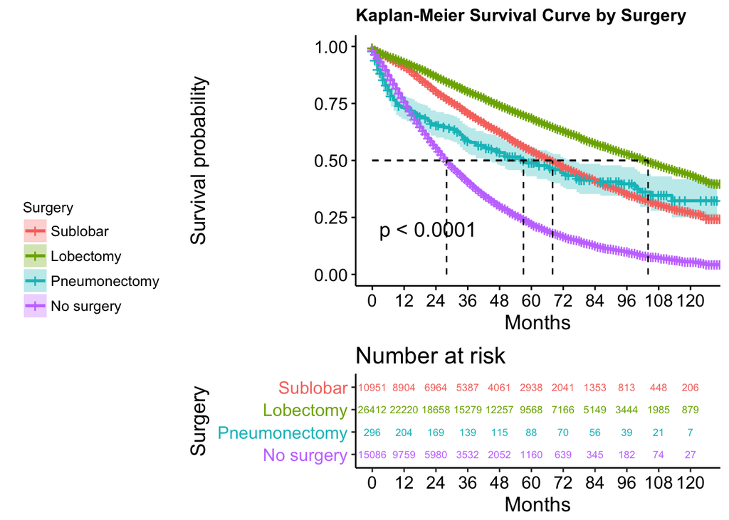

```r
fit7 <- survfit(Surv(surv, die2) ~ surgtype, data = dat_lung_analy, type = "kaplan-meier")
ggsurvplot(fit7, data = dat_lung_analy, pval=TRUE, risk.table.y.text.col = T,  title = "Kaplan-Meier Survival Curve by Surgery", font.title = c (12, "bold"), xlab = "Months",ylab = "Survival probability", legend = "left", legend.title = "Surgery", legend.labs = c("Sublobar", "Lobectomy", "Pneumonectomy", "No surgery"), conf.int = TRUE, risk.table = TRUE, risk.table.height = 0.35, risk.table.col = "strata", risk.table.fontsize = 2.5,break.time.by = 12, surv.median.line = "hv")
```

Wow. That’s very interesting! We can draw three major conclusions from this figure: (1) No surgery (purple line) is associated with worst prognosis with median survival <30 months; (2) Lobectomy is better than sublobar resection (Green vs red); (3) Pneumonectomy (blue) is associated with a high short-term death but can achieve better long-term survival compared with sublobar resection.

Above differences can be well explained: The most important cause of death in cancer patients is distal metastasis. Literally, the more you resected the tumor (R0 resection), the less chance of metastasis. However, the surgeons also want to keep the healthy tissue/organs as much as they can. Therefore, it is a kind of balance. Pneumonectomy is such a big surgery therefore many patients would die quickly because of different fatal complications. But the survivors are less likely to have metastasis. In contrast, sublobar resection is considered less invasive, but also easy to cause distal metastasis and yield relatively poor long-term survival.

Let’s ask another question: Does age impact on the surgery types choosing?

We can try to answer it with the following figure:

```r
library(tidyverse)
```

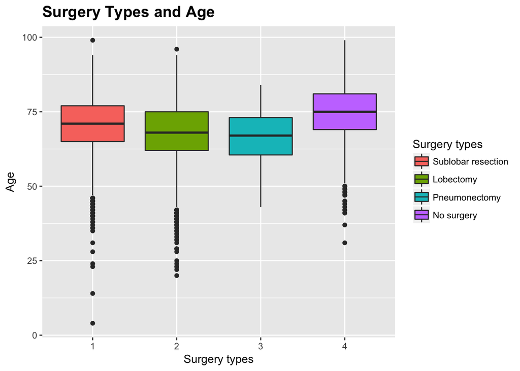

```r
dat_lung_analy %>% drop_na () %>% ggplot (aes(x=as.factor(surgtype), y=agedx, fill=as.factor(surgtype))) + geom_boxplot() + scale_fill_discrete(name = "Surgery types", breaks=c("1", "2", "3", "4"), labels=c("Sublobar resection", "Lobectomy", "Pneumonectomy", "No surgery")) + xlab("Surgery types") + ylab("Age") + ggtitle("Surgery Types and Age") + theme(plot.title = element_text(size=15, face="bold"))
```

This figure shows a trend that the patients are younger in more invasive surgery types. The no surgery group has the highest median age. Combined with our clinical experience, yes, age is an important issue that surgeons would concern when they choose the procedures. They may hesitate to operate on patients with age>80 because of the expected high complication rate. Likewise, aggressive procedure such as pneumonectomy would also be avoided in the elderly patients.

## Other risk factors

Let’s look at other risk factors:

Sex

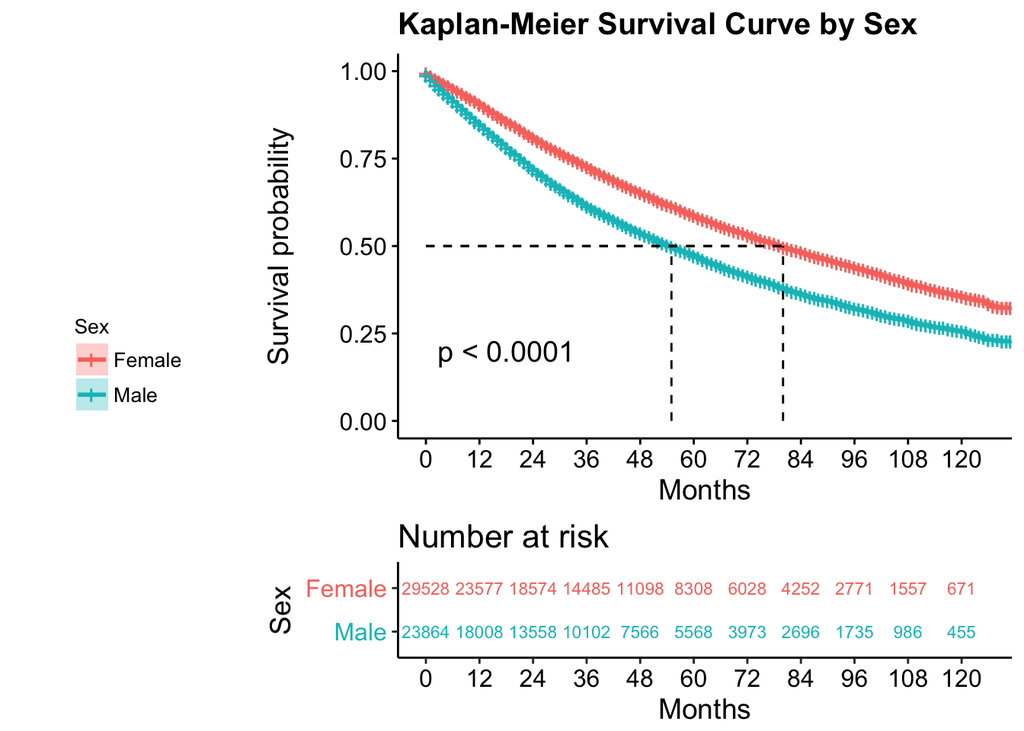

```r
fit <- survfit(Surv(surv, die2) ~ sex2, data = dat_lung_analy, type = "kaplan-meier")
ggsurvplot(fit, data = dat_lung_analy, pval=TRUE, risk.table.y.text.col = T,  title = "Kaplan-Meier Survival Curve by Sex", font.title = c (15, "bold"), xlab = "Months",ylab = "Survival probability", legend = "left", legend.title = "Sex", legend.labs = c("Female", "Male"), conf.int = TRUE, risk.table = TRUE, risk.table.height = 0.3, risk.table.col = "strata", risk.table.fontsize = 3,break.time.by = 12, surv.median.line = "hv")
```

Female has a better overall survival compared with man.

Race:

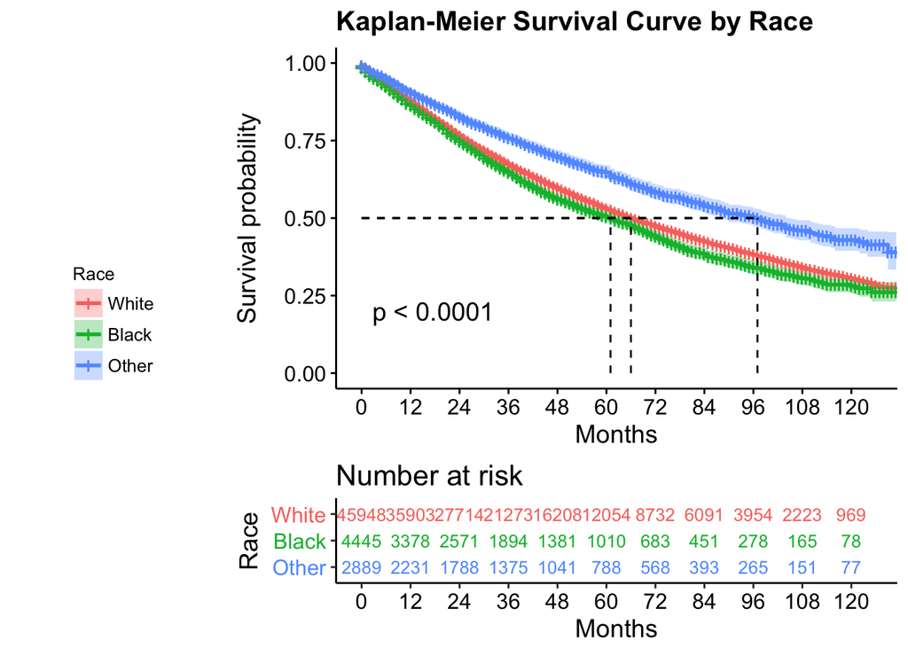

```r
fit3 <- survfit(Surv(surv, die2) ~ race3, data = dat_lung_analy, type = "kaplan-meier")
ggsurvplot(fit3, data = dat_lung_analy, pval=TRUE, risk.table.y.text.col = T,  title = "Kaplan-Meier Survival Curve by Race", font.title = c (15, "bold"), xlab = "Months",ylab = "Survival probability", legend = "left", legend.title = "Race", legend.labs = c("White", "Black", "Other"), conf.int = TRUE, risk.table = TRUE, risk.table.height = 0.3, risk.table.col = "strata", risk.table.fontsize = 3.5,break.time.by = 12, surv.median.line = "hv")
```

It seems that white patients have similar survival compared with African American patients. However, other races (mainly Hispanic and Asian) is associated with better survival.

Marital status:

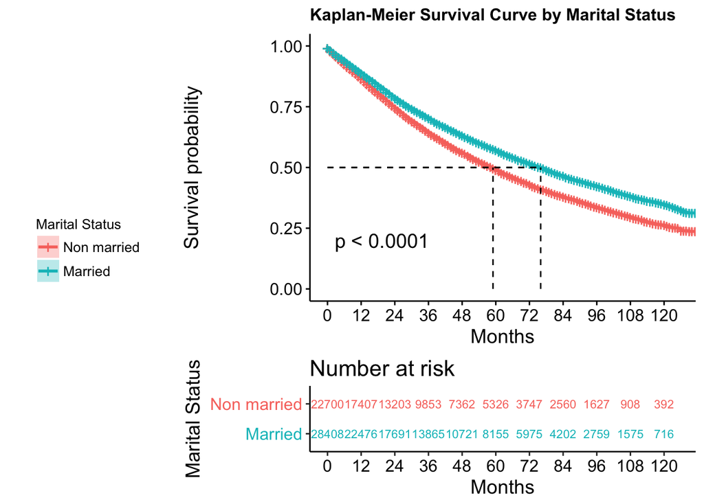

```r
fit4 <- survfit(Surv(surv, die2) ~ marstat2, data = dat_lung_analy, type = "kaplan-meier")
ggsurvplot(fit4, data = dat_lung_analy, pval=TRUE, risk.table.y.text.col = T,  title = "Kaplan-Meier Survival Curve by Marital Status", font.title = c (12, "bold"), xlab = "Months",ylab = "Survival probability", legend = "left", legend.title = "Marital Status", legend.labs = c("Non married", "Married"), conf.int = TRUE, risk.table = TRUE, risk.table.height = 0.3, risk.table.col = "strata", risk.table.fontsize = 3,break.time.by = 12, surv.median.line = "hv")
```

Aha! Marriage is a big issue.

Pathological types:

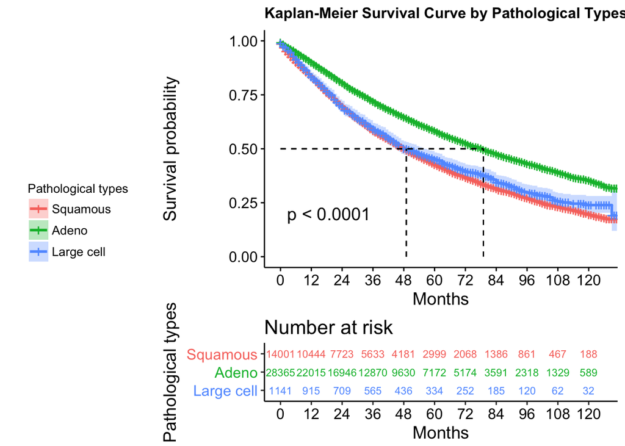

```r
fit5 <- survfit(Surv(surv, die2) ~ histo3_2, data = dat_lung_analy, type = "kaplan-meier")
ggsurvplot(fit5, data = dat_lung_analy, pval=TRUE, risk.table.y.text.col = T,  title = "Kaplan-Meier Survival Curve by Pathological Types",font.title = c (12, "bold"), xlab = "Months",ylab = "Survival probability", legend = "left", legend.title = "Pathological types", legend.labs = c("Squamous", "Adeno", "Large cell"), conf.int = TRUE, risk.table = TRUE, risk.table.height = 0.3, risk.table.col = "strata", risk.table.fontsize = 3, break.time.by = 12, surv.median.line = "hv")
```

Adenocarcinoma is associated with better survival compared with squamous cell carcinoma.

Grade:

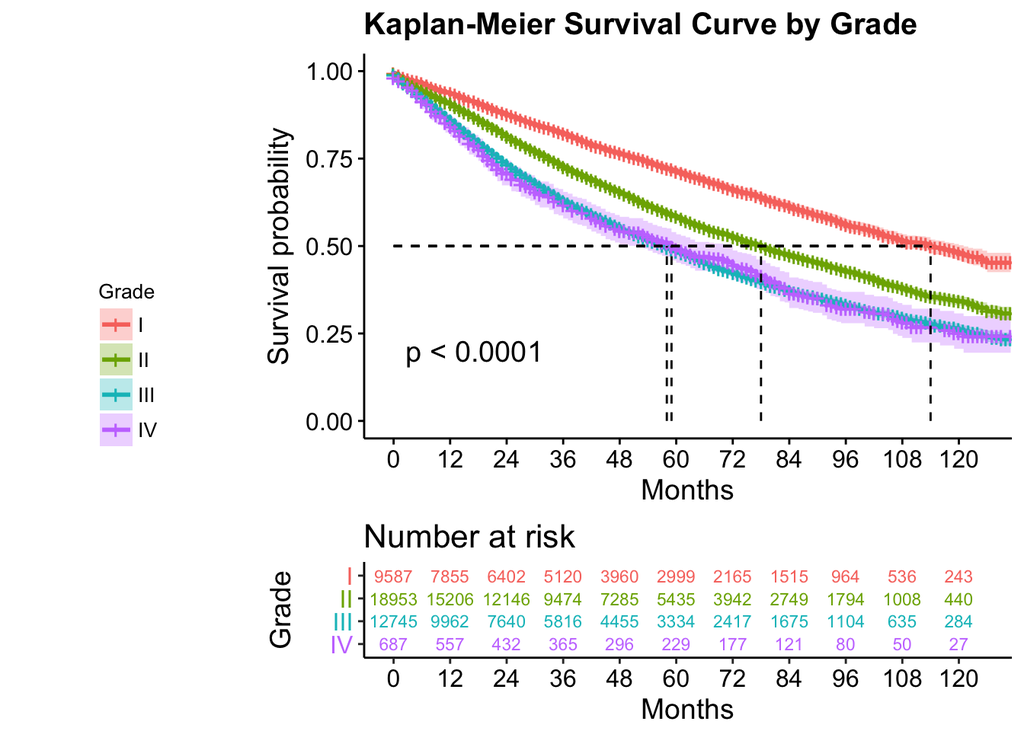

```r
fit6 <- survfit(Surv(surv, die2) ~ grade2, data = dat_lung_analy, type = "kaplan-meier")
ggsurvplot(fit6, data = dat_lung_analy, pval=TRUE, risk.table.y.text.col = T,  title = "Kaplan-Meier Survival Curve by Grade", font.title = c (15, "bold"), xlab = "Months",ylab = "Survival probability", legend = "left", legend.title = "Grade", legend.labs = c("I", "II", "III", "IV"), conf.int = TRUE, risk.table = TRUE, risk.table.height = 0.3, risk.table.col = "strata", risk.table.fontsize = 3,break.time.by = 12, surv.median.line = "hv")
```

## Interactions

Is there any association between pathological types and grade??

```r
library(gridExtra)
```

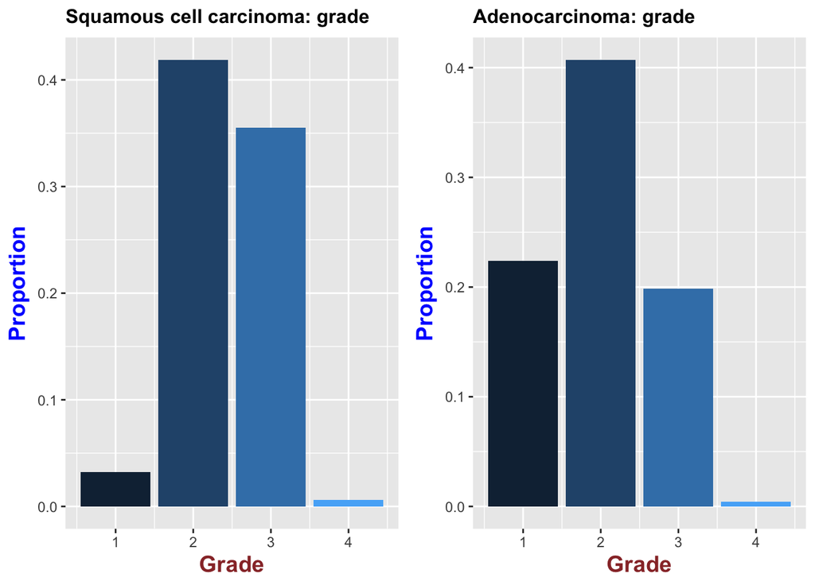

```r
p1 <- dat_lung_analy %>% filter(histo3_2==1) %>% group_by(grade2) %>%
  summarize(n = n()) %>%
  mutate(Proportion = n/sum(n)) %>%
  ggplot(aes(x=grade2, y=Proportion, fill=grade2)) +
  geom_bar(stat = "identity", show.legend = FALSE) +
  xlab("Grade") +
  ylab("Proportion") +
  ggtitle("Squamous cell carcinoma: grade") +
  theme(plot.title = element_text(color="Black", size=12, face="bold"),
axis.title.x = element_text(color="#993333", size=14, face="bold"),
axis.title.y = element_text(color="blue", size=14, face="bold"))

p2 <- dat_lung_analy %>% filter(histo3_2==2) %>% group_by(grade2) %>%
  summarize(n = n()) %>%
  mutate(Proportion = n/sum(n)) %>%
  ggplot(aes(x=grade2, y=Proportion, fill=grade2)) +
  geom_bar(stat = "identity", show.legend = FALSE) +
  xlab("Grade") +
  ylab("Proportion") +
  ggtitle("Adenocarcinoma: grade") +
  theme(plot.title = element_text(color="Black", size=12, face="bold"),
axis.title.x = element_text(color="#993333", size=14, face="bold"),
axis.title.y = element_text(color="blue", size=14, face="bold"))

grid.arrange(p1, p2, ncol =2)
```

We realize that the most of the squamous cell carcinoma patients were in grade 2 and 3, while most adenocarcinoma patients were in grade 1 and 2. Would the higher grades of tumor contribute to the poor prognosis of squamous cell carcinoma? We believe it could be an interaction between grade and pathological types.

## Propensity Score Matching

Let’s go back to surgery types. We want to look at if we controlled all available potential confounders, is lobectomy still better sublobar resection in terms of long-term survival?

Here we use the propensity score matching approach:

```r
library(MatchIt)
dat_lung_psa <- dat_lung_analy %>% filter(surgtype == c(1,2))
dat_lung_psa$surgtype2 [dat_lung_psa$surgtype==1] <- 0
dat_lung_psa$surgtype2 [dat_lung_psa$surgtype==2] <- 1
dat_lung_psa <- dat_lung_psa[complete.cases(dat_lung_psa), ]
```

```r
lung.match = matchit(surgtype2 ~ agec_per10 + sex2 + race3 + histo3_2 + grade2 + marstat2,
data = dat_lung_psa, method = "nearest",
ratio = 1)
lung.match
```

```
##
## Call:
## matchit(formula = surgtype2 ~ agec_per10 + sex2 + race3 + histo3_2 +
##     grade2 + marstat2, data = dat_lung_psa, method = "nearest",
##     ratio = 1)
##
## Sample sizes:
##           Control Treated
## All          3960   10040
## Matched      3960    3960
## Unmatched       0    6080
## Discarded       0       0
```

Now it becomes 3960 sublobar resection vs 3960 lobectomy.

These two figures show the propensity scores information:

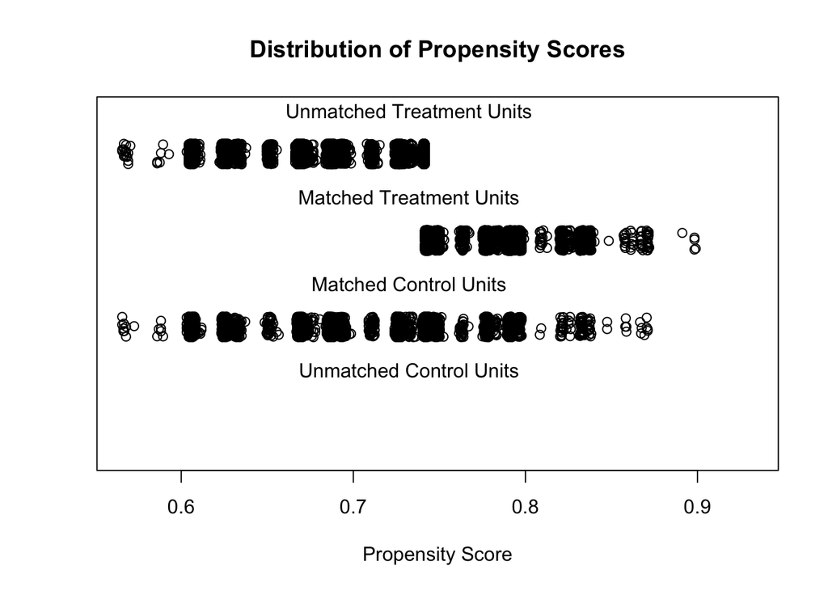

```
## [1] "To identify the units, use first mouse button; to stop, use second."
```

```
## integer(0)
```

```r
plot(lung.match, type = "jitter")
```

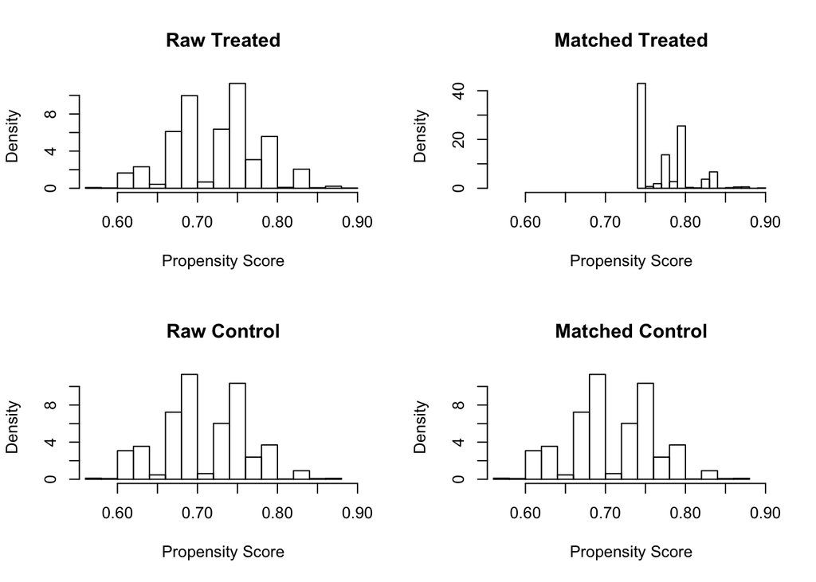

```r
plot(lung.match, type = "hist")
```

Let’s do the survival analysis for the matched groups:

```r
dat_lung_match <- match.data(lung.match)
```

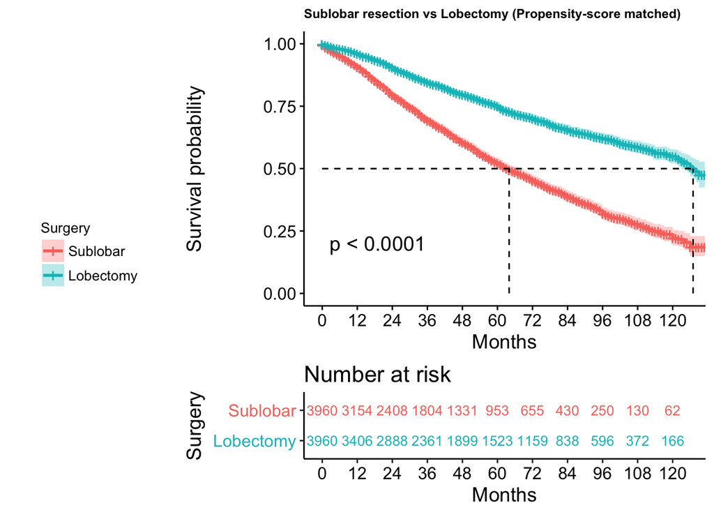

```r
fit8 <- survfit(Surv(surv, die2) ~ surgtype2, data = dat_lung_match, type = "kaplan-meier")
ggsurvplot(fit8, data = dat_lung_match, pval=TRUE, risk.table.y.text.col = T,  title = "Sublobar resection vs Lobectomy (Propensity-score matched)", font.title = c (9, "bold"), xlab = "Months",ylab = "Survival probability", legend = "left", legend.title = "Surgery", legend.labs = c("Sublobar", "Lobectomy"), conf.int = TRUE, risk.table = TRUE, risk.table.height = 0.3, risk.table.col = "strata", risk.table.fontsize = 3.5,break.time.by = 12, surv.median.line = "hv")
```

The results demonstrated that the difference in overall survival becomes even more significant between two procedures.

### Cox regression

Finally, we fit all the variables with a Cox regression model (here we put age as a continuous variable):

```r
mod1 <- coxph(Surv(surv, die2) ~ sex2+as.factor(race3)+agedx+marstat2+as.factor(histo3_2)+as.factor(surgtype)+as.factor(grade2), data=dat_lung_analy)
summary(mod1)
```

```
## Call:
## coxph(formula = Surv(surv, die2) ~ sex2 + as.factor(race3) +
##     agedx + marstat2 + as.factor(histo3_2) + as.factor(surgtype) +
##     as.factor(grade2), data = dat_lung_analy)
##
##   n= 34106, number of events= 13403
##    (19286 observations deleted due to missingness)
##
##                           coef exp(coef)  se(coef)       z Pr(>|z|)
## sex2                  0.346533  1.414157  0.018232  19.007  < 2e-16 ***
## as.factor(race3)2     0.045371  1.046416  0.031854   1.424 0.154348
## as.factor(race3)3    -0.264456  0.767624  0.045202  -5.851 4.90e-09 ***
## agedx                 0.028781  1.029199  0.001017  28.313  < 2e-16 ***
## marstat2             -0.158444  0.853471  0.018335  -8.641  < 2e-16 ***
## as.factor(histo3_2)2 -0.209672  0.810850  0.018932 -11.075  < 2e-16 ***
## as.factor(histo3_2)3  0.102460  1.107893  0.056945   1.799 0.071974 .
## as.factor(surgtype)2 -0.372401  0.689078  0.021466 -17.348  < 2e-16 ***
## as.factor(surgtype)3  0.334928  1.397840  0.092821   3.608 0.000308 ***
## as.factor(surgtype)4  0.766494  2.152207  0.025209  30.406  < 2e-16 ***
## as.factor(grade2)2    0.314609  1.369724  0.027990  11.240  < 2e-16 ***
## as.factor(grade2)3    0.406793  1.501993  0.029599  13.743  < 2e-16 ***
## as.factor(grade2)4    0.354772  1.425856  0.074021   4.793 1.64e-06 ***
## ---
## Signif. codes:  0 '***' 0.001 '**' 0.01 '*' 0.05 '.' 0.1 ' ' 1
##
##                      exp(coef) exp(-coef) lower .95 upper .95
## sex2                    1.4142     0.7071    1.3645    1.4656
## as.factor(race3)2       1.0464     0.9556    0.9831    1.1138
## as.factor(race3)3       0.7676     1.3027    0.7025    0.8387
## agedx                   1.0292     0.9716    1.0272    1.0313
## marstat2                0.8535     1.1717    0.8233    0.8847
## as.factor(histo3_2)2    0.8108     1.2333    0.7813    0.8415
## as.factor(histo3_2)3    1.1079     0.9026    0.9909    1.2387
## as.factor(surgtype)2    0.6891     1.4512    0.6607    0.7187
## as.factor(surgtype)3    1.3978     0.7154    1.1653    1.6767
## as.factor(surgtype)4    2.1522     0.4646    2.0485    2.2612
## as.factor(grade2)2      1.3697     0.7301    1.2966    1.4470
## as.factor(grade2)3      1.5020     0.6658    1.4173    1.5917
## as.factor(grade2)4      1.4259     0.7013    1.2333    1.6485
##
## Concordance= 0.685  (se = 0.003 )
## Rsquare= 0.145   (max possible= 1 )
## Likelihood ratio test= 5334  on 13 df,   p=0
## Wald test            = 5723  on 13 df,   p=0
## Score (logrank) test = 6252  on 13 df,   p=0
```

Here we find many statistically significant risk factors, such as no surgery which has a coefficient 0.77, indicating that it impacts the prognosis a lot.

## Conclusion and future work

We have explored many factors and found they are highly associated with long-term survival of stage IA NSCLC. Compared with lobectomy, sublobar resection is associated with a significantly worse overall survival. There might be interactions between the pathological types and grade.

We plan to focus our future work on revise the Cox regression model such as adding the interactions. In addition, recent clinical studies reported that the sublobar resection can achieve similar efficacy with lobectomy [6, 7]. We need to compare our findings with them and figure out the causes of the differences.

## References

1. Siegel RL, Miller KD, Jemal A. Cancer Statistics, 2017. CA Cancer J Clin 2017;67(1):7-30.
2. Midthun DE. Overview of the initial evaluation, treatment and prognosis of lung cancer. UpToDate (accessed Dec 10, 2017)
3. Thomas KW, Gould MK. Tumor, Node, Metastasis (TNM) staging system for lung cancer. UpToDate (accessed Dec 10, 2017)
4. SEER website. https://seer.cancer.gov/about/ (accessed Dec 10, 2017)
5. Hinyard L, Wirth LS, Clancy JM, Schwartz T. The effect of marital status on breast cancer-related outcomes in women under 65: A SEER database analysis. Breast 2017;32:13-17.
6. Gu C, Wang R, Pan X, Huang Q, Zhang Y, Yang J, Shi J. Sublobar resection versus lobectomy in patients aged ≤35 years with stage IA non-small cell lung cancer: a SEER database analysis. J Cancer Res Clin Oncol 2017;143(11):2375-2382.
7. Dziedzic R, Zurek W, Marjanski T, Rudzinski P, Orlowski TM, Sawicka W, Marczyk M, Polanska J, Rzyman W. Stage I non-small-cell lung cancer: long-term results of lobectomy versus sublobar resection from the Polish National Lung Cancer Registry. Eur J Cardiothorac Surg 2017;52(2):363-369.